# Logistic regression: Part I

```r
library(ggplot2)
library(dplyr)
```

# Getting started

**Where are we?**

We’ve been focusing on “Normal” linear regression models for **quantitative** response variables. But not all response variables are quantitative! We’ll now explore logistic regression models for **binary categorical** response variables. Though the details of our models will change, the spirit and considerations are the same (eg: we still want to learn about y from predictors x and still need to be mindful of multicollinearity, overfitting, etc).

**Warm-up exercise: Normal or logistic?**

For each scenario below, indicate whether Normal or logistic regression would be the appropriate modeling tool.

**Logistic Regression**

Let $y$ be a binary categorical response variable:

$$y =
\begin{cases}
1 & \; \text{ if event happens} \\
0 & \; \text{ if event doesn't happen} \\
\end{cases}$$

Further define

$$\begin{split}
p &= \text{ probability event happens} \\
1-p &= \text{ probability event doesn't happen} \\
\text{odds} & = \text{ odds event happens} = \frac{p}{1-p} \\
\end{split}$$

Then a logistic regression model of $y$ by $x$ is
$$\log(\text{odds}) = \beta_0 + \beta_1 x$$

We can transform this to get (curved) models of odds and probability:

$$\begin{split}
\text{odds} & = e^{\beta_0 + \beta_1 x} \\
p & = \frac{\text{odds}}{\text{odds}+1} = \frac{e^{\beta_0 + \beta_1 x}}{e^{\beta_0 + \beta_1 x}+1} \\
\end{split}$$

**Coefficient interpretation**

$$\begin{split}
\beta_0 & = \text{ LOG(ODDS) when } x=0 \\
e^{\beta_0} & = \text{ ODDS when } x=0 \\
\beta_1 & = \text{ unit change in LOG(ODDS) per 1 unit increase in } x \\
e^{\beta_1} & = \text{ multiplicative change in ODDS per 1 unit increase in } x \\
\end{split}$$

# Exercises

**Directions**

There is a lot of new and specialized syntax today. Not even the professor has this syntax committed to memory. During class, you’re encouraged to peak at but not get distracted by the syntax – stay focused on the bigger picture concepts. After the activity / after class, go back and pick through the syntax.

**The story**

The `climbers_sub` data is sub-sample of the [Himalayan Database](https://www.himalayandatabase.com/) distributed through the [R for Data Science TidyTuesday project](https://github.com/rfordatascience/tidytuesday/tree/master/data/2020/2020-09-22). This dataset includes information on the results and conditions for various Himalayan climbing expeditions. Each row corresponds to a single member of a climbing expedition team:

```r
climbers_sub <- read.csv("https://www.macalester.edu/~ajohns24/data/climbers_sub.csv") %>%
  select(peak_name, success, age, oxygen_used, height_metres)

head(climbers_sub)
```

```
##    peak_name success age oxygen_used height_metres
## 1 Ama Dablam    TRUE  28       FALSE          6814
## 2 Ama Dablam    TRUE  27       FALSE          6814
## 3 Ama Dablam    TRUE  35       FALSE          6814
## 4 Ama Dablam    TRUE  37       FALSE          6814
## 5 Ama Dablam    TRUE  43       FALSE          6814
## 6 Ama Dablam   FALSE  38       FALSE          6814
```

Our goal will be to model whether or not a climber has `success` by their `age`. Since `success` is a binary categorical variable (a climber is either successful or they’re not), we’ll utilize **logistic regression**.

## Exercise 1: Hello!

Please check in with one another.

## Exercise 2: Warm-up: probability vs odds vs log(odds)

1. Let $p$ denote the probability of an event. Identify examples of events for which: $p=0$, $p=1$
   $$\begin{align} P(x \land \sim x) &= 0 & P(x \lor \sim x) = 1 \end{align}$$
2. There’s a 0.9 probability that the instructor joins your breakout room in the next 15 minutes. Calculate the corresponding *odds* and *log(odds)* of this event.
   $$\begin{align}
   odds_{instr} &= \frac{0.9}{1 - 0.9} = 9 \\
   \log(odds_{inst}) &= \log 9 = 2.19
   \end{align}$$
3. The log(odds) that your bus is late are -1. Calculate the corresponding *odds* and *probability* of this event.

## Exercise 3: A quick peak at the data

```r
# How many climbers are in the data set?
nrow(climbers_sub)
```

```
## [1] 2076
```

```r
# Overall, how many climbers succeeded / didn't succeed? Hint: n()
climbers_sub %>%
  group_by(success) %>%
  count()
```

```
## # A tibble: 2 x 2
## # Groups:   success [2]
##   success     n
##   <lgl>   <int>
## 1 FALSE    1269
## 2 TRUE      807
```

## Exercise 4: Plotting success by age

It’s not often easy to visualize a relationship between a binary response y and a predictor x. But since we have a large data set and multiple (though sometimes not many) observations at each age, we can calculate the observed success rate at each age. Try out the plots below and summarize what you learn.

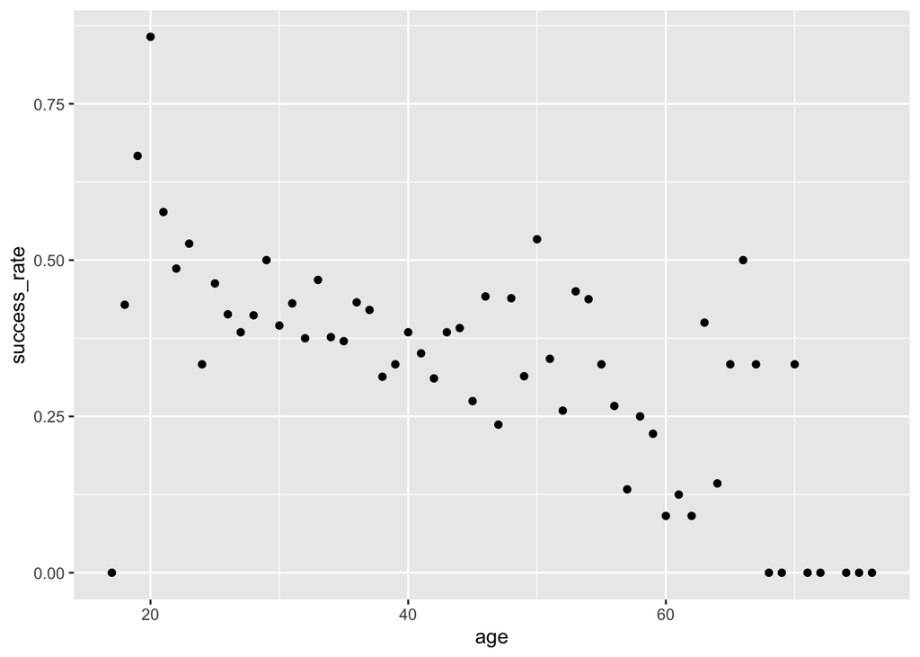

```r
# Calculate success rate by age
# And plot success rate by age
success_by_age <- climbers_sub %>%
  group_by(age) %>%
  summarize(success_rate = mean(success))
ggplot(success_by_age, aes(x = age, y = success_rate)) +
  geom_point()
```

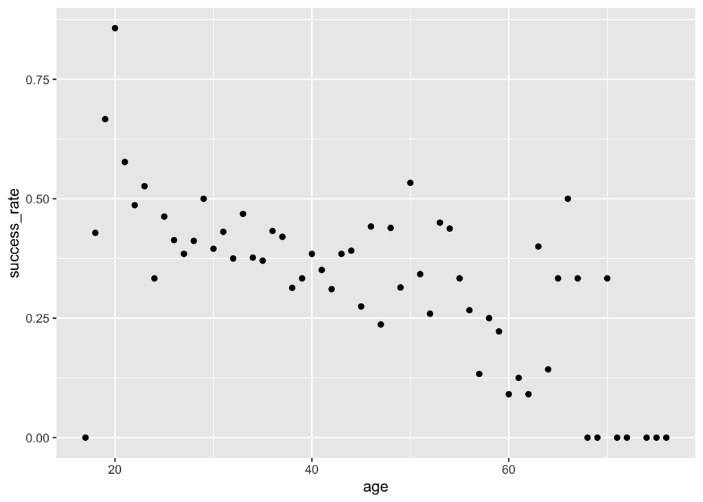

```r
# Do the above in 1 set of lines!
climbers_sub %>%
  group_by(age) %>%
  summarize(success_rate = mean(success)) %>%
  ggplot(aes(x = age, y = success_rate)) +
    geom_point()
```

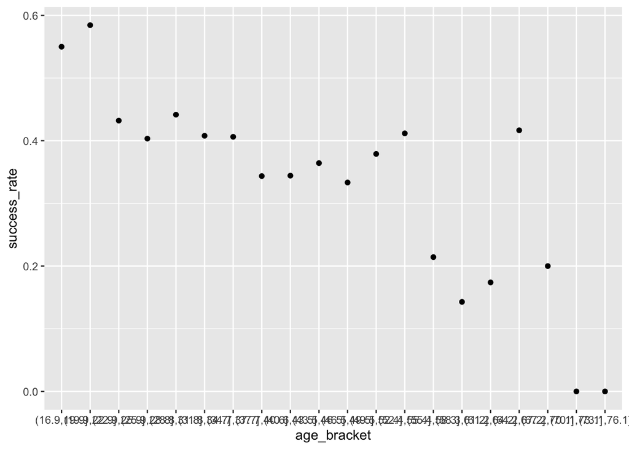

```r
# Split climbers into larger, more stable age brackets
# (This is good when we don't have many / multiple observations at each x!)
# Plot success rate by age bracket
climbers_sub %>%
  mutate(age_bracket = cut(age, breaks = 20)) %>%
  group_by(age_bracket) %>%
  summarize(success_rate = mean(success)) %>%
  ggplot(aes(x = age_bracket, y = success_rate)) +
    geom_point()
```

## Exercise 5: Logistic regression in R

To model the relationship between `success` and `age`, we can construct the **logistic regression model**. NOTE: For logistic regression we use `glm()` instead of `lm()` and use `family = "binomial"` to specify that our response variable is binary.

```r
climbing_model_1 <- glm(success ~ age, climbers_sub, family = "binomial")
summary(climbing_model_1)$coefficients
```

```
##                Estimate  Std. Error   z value     Pr(>|z|)
## (Intercept)  0.42568563 0.169177382  2.516209 1.186249e-02
## age         -0.02397199 0.004489504 -5.339564 9.317048e-08
```

Convince yourself that the model formulas on the log(odds), odds, and probability scales are as follows:

log(odds of success) = 0.42569 - 0.02397age  
odds of success = e^(0.42569 - 0.02397age)  
probability of success = e^(0.42569 - 0.02397age) / (e^(0.42569 - 0.02397age) + 1)

## Exercise 6: Plotting the model

We now have the *same* model of success by age, but on 3 different scales. Construct and comment on the plots below – what do they indicate about the relationship between climber success and age?

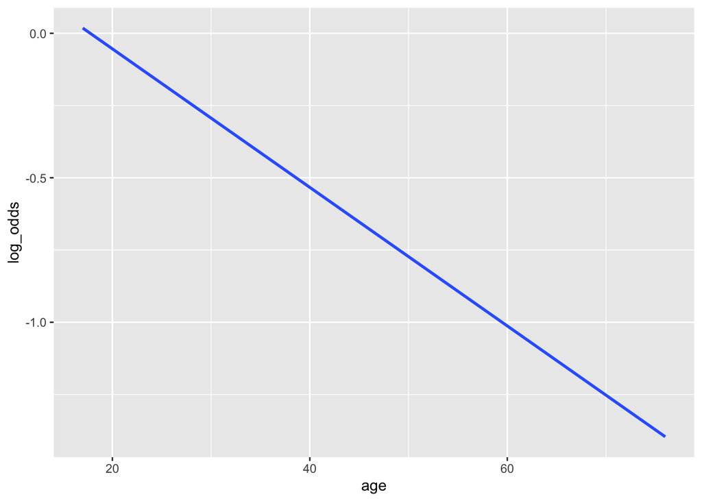

```r
# Incorporate predictions on the probability, odds, & log-odds scales
climbers_predictions <- climbers_sub %>%
  mutate(probability = climbing_model_1$fitted.values) %>%
  mutate(odds = probability / (1-probability)) %>%
  mutate(log_odds = log(odds))

# Plot the model on 3 scales
ggplot(climbers_predictions, aes(x = age, y = log_odds)) +
  geom_smooth(se = FALSE)
```

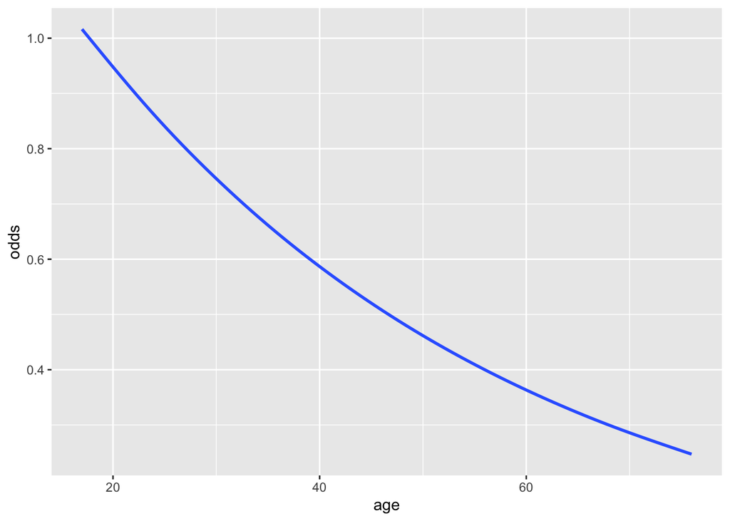

```r
ggplot(climbers_predictions, aes(x = age, y = odds)) +
  geom_smooth(se = FALSE)
```

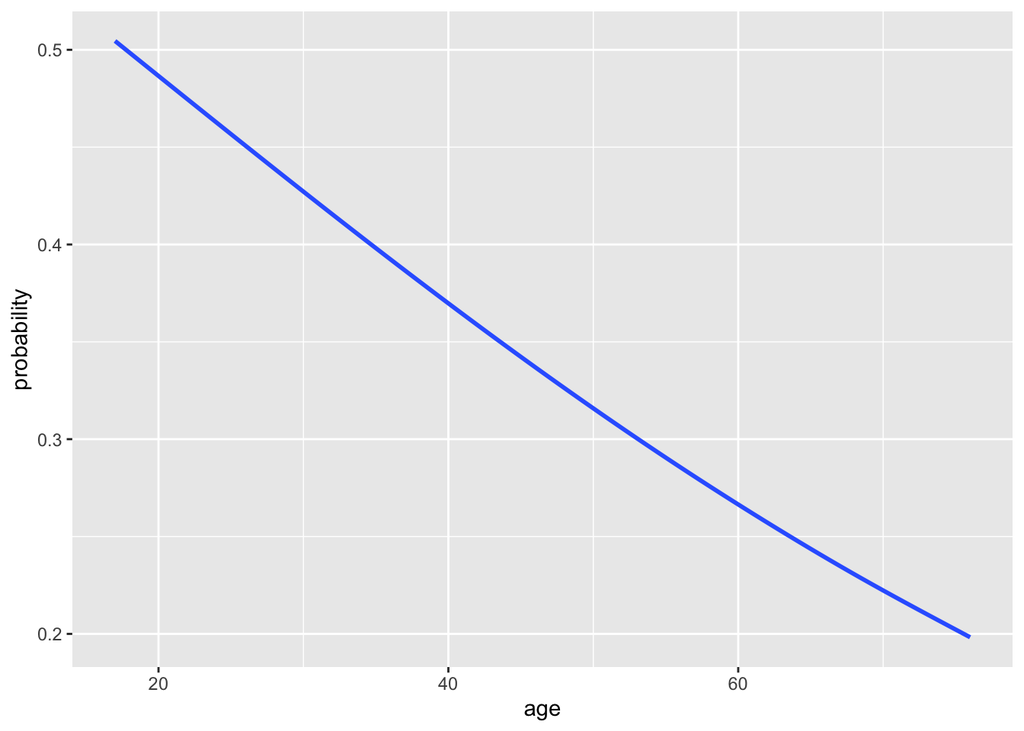

```r
ggplot(climbers_predictions, aes(x = age, y = probability)) +
  geom_smooth(se = FALSE)
```

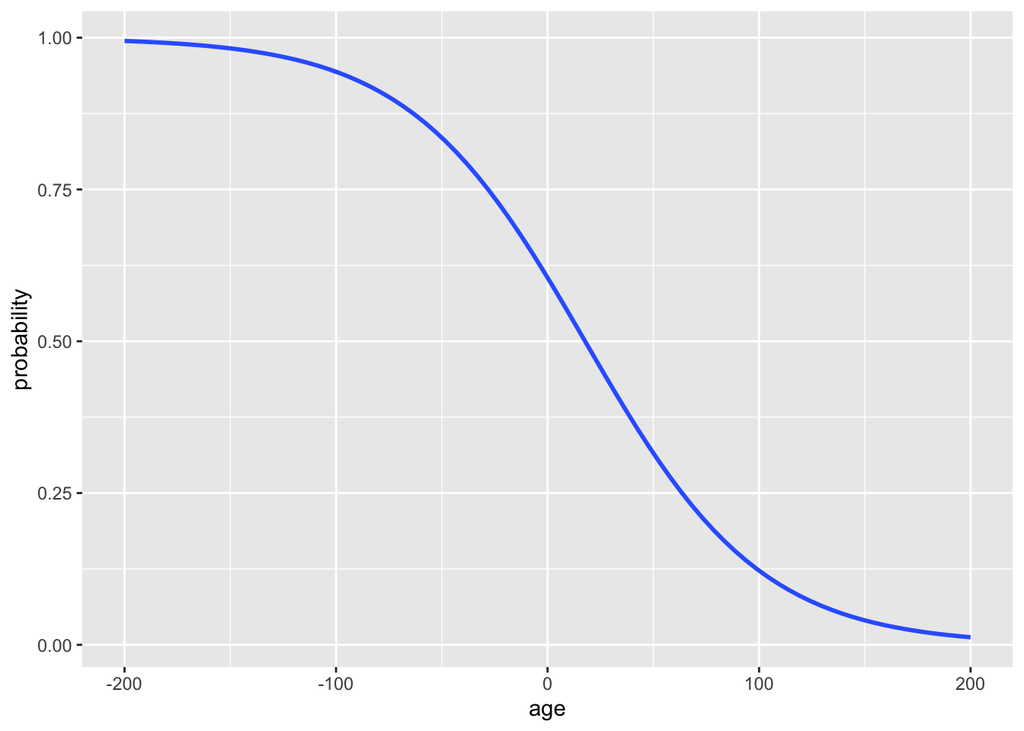

```r
#...and zoom out to see broader (and impossible) age range
ggplot(climbers_predictions, aes(x = age, y = as.numeric(success))) +
  geom_smooth(method = "glm", method.args = list(family = "binomial"), se = FALSE, fullrange = TRUE) +
  labs(y = "probability") +
  lims(x = c(-200,200))
```

## Exercise 8: Predictions

Let’s use the model to make predictions. Consider a 20 year old climber.

1. Predict the *log(odds)* that this climber will succeed. HINT: use the log(odds) model.

```r
0.42569 - 0.02397 * 20
```

```
## [1] -0.05371
```

2. Predict the *odds* that this climber will succeed. HINT: Either transform the log(odds) prediction or use the odds model.

```r
exp(0.42569 - 0.02397 * 20)
```

```
## [1] 0.9477069
```

3. Predict the *probability* that this climber will succeed. HINT: Either transform the odds prediction or use the probability model.

```r
exp(0.42569 - 0.02397 * 20) / (1 + exp(0.42569 - 0.02397 * 20))
```

```
## [1] 0.4865757
```

## Exercise 9: Checking predictions

1. On each of the 3 scales, are your predictions consistent with your model visualizations above?
2. Check your predictions using the following picky syntax.

```r
# Check the log-odds prediction
predict(climbing_model_1, newdata = data.frame(age = 20))
```

```
##           1
## -0.05375421
```

```r
# Check the odds prediction
exp(predict(climbing_model_1, newdata = data.frame(age = 20)))
```

```
##        1
## 0.947665
```

```r
# Check the probability prediction
predict(climbing_model_1, newdata = data.frame(age = 20), type = "response")
```

```
##         1
## 0.4865647
```

## Exercise 10: Interpreting Coefficients

You’ll learn more in tomorrow’s video about interpreting logistic regression coefficients. Give it a quick try here.

1. Interpret the intercept coefficient on the log(odds) scale. NOTE: You can do this just as you did for “Normal” regression models, but remember that the response here is log(odds of success).  
   When age is 0, log odds of success is 0.42569.
2. Interpret the intercept coefficient on the odds scale. HINT: `exp()`  
   When age is 0, odds of success is exp(0.42569).
3. Interpret the `age` coefficient on the log(odds) scale. NOTE: You can do this just as you did for “Normal” regression models, but remember that the response here is log(odds of success).

4. The log(odds) scale isn’t very nice. We can convert this to the odds scale as follows. If the `age` coefficient on the log(odds) scale is **b**, then **e^b** is the MULTIPLICATIVE change in ODDS of success per 1 year increase in age.
5. **EXTRA:** Try to *prove* the relationship used in part d

Follows from definition.

# Optional extra exercises

## Exercise 11: Another climbing model

1. Construct a model of `success` by `oxygen_used`.

```r
climbing_model_2 <- glm(success ~ oxygen_used, climbers_sub, family = "binomial")
summary(climbing_model_1)$coefficients
```

[output not shown]

```
##                Estimate  Std. Error   z value     Pr(>|z|)
## (Intercept)  0.42568563 0.169177382  2.516209 1.186249e-02
## age         -0.02397199 0.004489504 -5.339564 9.317048e-08
```

```r
# predict(climbing_model_2, newdata = data_frame(FALSE))
```

3. Interpret the two model coefficients.